# Exploratory Data Analysis

Rob Leonard (robleonard@tamu.edu)

**Initial Data setup.**

```r
library(quantmod)
getSymbols(c("^GSPC","CSCO","C","CVX","AMZN"), from = "1991-01-01", to = "2021-02-01")
```

[output not shown]

```
## [1] "^GSPC" "CSCO"  "C"     "CVX"   "AMZN"
```

# Question 1: S&P 500 Index

**Part a: Plot adjusted closing price and daily log returns.**

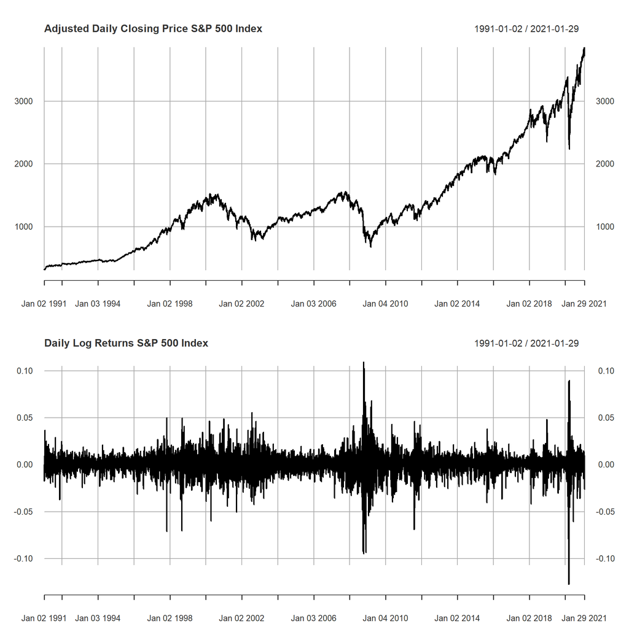

```r
par(mfrow   = c(2, 1))
plot(Ad(GSPC), main="Adjusted Daily Closing Price S&P 500 Index")
plot(dailyReturn(Ad(GSPC), type="log"), main="Daily Log Returns S&P 500 Index")
```

**Part b: Describe the two plots accounting for macroeconomic events and compare to NASDAQ.**  
The adjusted closing price plot at the top corresponds to major macroeconomic events with the index peaking just before major crises. The first peak in early 2000 followed by a steep price decline corresponds to the 2000 dot com technology stock bust and national recession. Similarly, the peak in late 2007 and subsequent price decline corresponds to the 2008 financial crisis and recession (housing overvaluations, fraud, bankruptcies of Lehman Bros. and Bear Sterns). Another sharp market drop in early 2020 corresponds to the current COVID pandemic and recession. Volatility in returns is significantly higher in the three crisis periods.

Compared to the NASDAQ, the S&P 500 index was more affected by the 2008 and 2020 crises than the 2000 dot com bubble. The NASDAQ was more affected by the 2000 dot com bubble, with a maximum log return loss of 30%. The NASDAQ was also affected by the 2008 financial crisis and the 2020 pandemic, but these events had less impact as compared to the dot com bubble and compared to the impact these events had on the S&P 500.

The S&P 500 Index shares some of the stlyized facts with the NASDAQ:  
*Stationarity:* index prices don’t appear stationary, but expansionary post-crisis following economic growth, federal and monetary stimulus and technology advancement. Returns do appear stationary however, following a mean daily return of close to 0%.

*Asymmetery:* returns again appear negatively skewed with downturns steeper than recoveries, but more short lived. The negative skew here seems slighltly less pronounced compared to the NASDAQ.

# Question 2: Cisco, Citigroup & Chevron

**Part a: Plot adjusted closing price and daily log returns.**

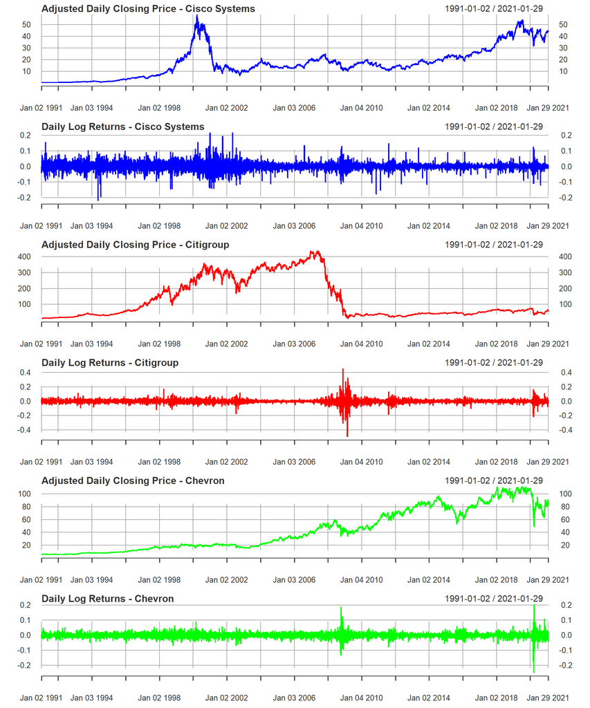

```r
par(mfrow   = c(6, 1))
plot(Ad(CSCO), main="Adjusted Daily Closing Price - Cisco Systems", col="blue")
plot(dailyReturn(Ad(CSCO), type="log"), main="Daily Log Returns - Cisco Systems", col="blue")
plot(Ad(C), main="Adjusted Daily Closing Price - Citigroup", col="red")
plot(dailyReturn(Ad(C), type="log"), main="Daily Log Returns - Citigroup", col="red")
plot(Ad(CVX), main="Adjusted Daily Closing Price - Chevron", col="green")
plot(dailyReturn(Ad(CVX), type="log"), main="Daily Log Returns - Chevron", col="green")
```

# Question 3: COVID 19 Impact

**Part a: Plot adjusted closing price and daily log returns for the S&P 500 Index from 2019 onwards.**

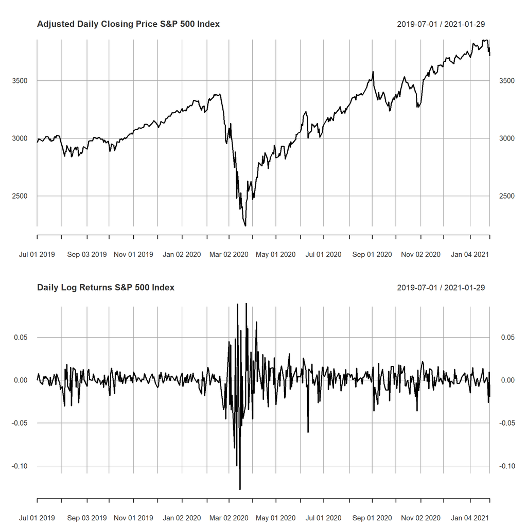

```r
par(mfrow   = c(2, 1))
plot(Ad(GSPC["2019-07-01::2021-02-01"]), main="Adjusted Daily Closing Price S&P 500 Index")
plot(dailyReturn(Ad(GSPC["2019-07-01::2021-02-01"]), type="log"), main="Daily Log Returns S&P 500 Index")
```

The plots indicate high return volatility and ongoing price declines at the start of the COVID 19 pandemic in the spring of 2020. This decline was then offset by a period of upward trending price appreciation and periods of lower return volatility as compared to the start of the pandemic. However, volatility remains higher during the pandemic than it was in the year preceeding the pandemic.

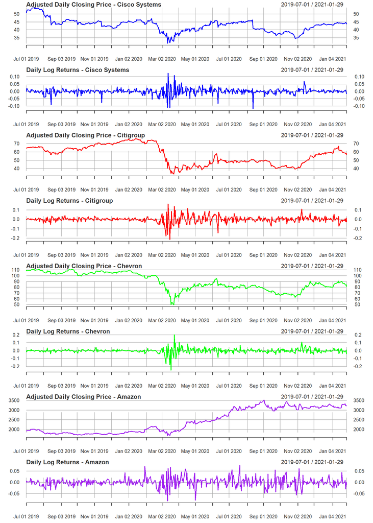

```r
par(mfrow   = c(8, 1))
plot(Ad(CSCO["2019-07-01::2021-02-01"]), main="Adjusted Daily Closing Price - Cisco Systems", col="blue")
plot(dailyReturn(Ad(CSCO["2019-07-01::2021-02-01"]), type="log"), main="Daily Log Returns - Cisco Systems", col="blue")
plot(Ad(C["2019-07-01::2021-02-01"]), main="Adjusted Daily Closing Price - Citigroup", col="red")
plot(dailyReturn(Ad(C["2019-07-01::2021-02-01"]), type="log"), main="Daily Log Returns - Citigroup", col="red")
plot(Ad(CVX["2019-07-01::2021-02-01"]), main="Adjusted Daily Closing Price - Chevron", col="green")
plot(dailyReturn(Ad(CVX["2019-07-01::2021-02-01"]), type="log"), main="Daily Log Returns - Chevron", col="green")
plot(Ad(AMZN["2019-07-01::2021-02-01"]), main="Adjusted Daily Closing Price - Amazon", col="purple")
plot(dailyReturn(Ad(AMZN["2019-07-01::2021-02-01"]), type="log"), main="Daily Log Returns - Amazon", col="purple")
```

# Question 4: Chevron

**Part a: Historgram.**

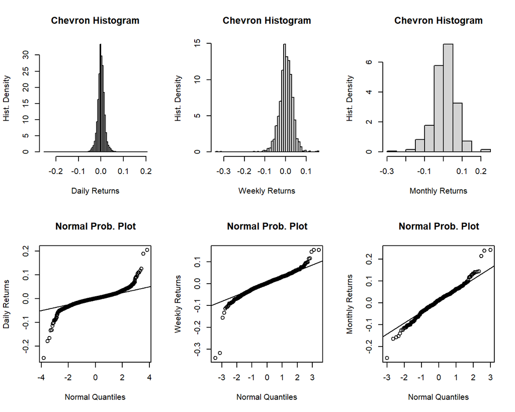

**Part b: Comment on Plots.**  
The daily return histogram and normal probability plot indicate that the daily return data is not normally distributed. The daily returns have a much higher peak and longer tails than the standard normal curve. The deviation from the straight line on the normal probability plot indicate longer left and right tails. The weekly returns are slightly more normal but still have longer tails at both sides and thus do not appear to be sufficiently normal. The monthly returns are much closer with only some slight deviation from the line in the normal probability plot (again indicating slightly longer tails), but this would likely be close enough to be considered approximately normal.

**Part c: Calculate skewness and kurtosis. Run Shapiro-Wilkes and Jarque-Bera tests.**

```r
Sk.fun <- function(x) { ## function to compute skewness from HO 3
  mean((x-mean(x))^3/sd(x)^3)
}
Kur.fun <- function(x){ ## function to compute kurtosis
  mean((x-mean(x))^4/sd(x)^4)
}
JB.test <- function(x) { ## Jarque-Bera Test
  JB <-length(x)*(Sk.fun(x)^2/6+(Kur.fun(x)-3)^2/24)
  list(stat = JB, pvalue = 1-pchisq(JB,2))
}

resultsP4 = matrix(rep(0,18),ncol=3)  # set up a results matrix to gather calcs

for (i in 1:3) {
  resultsP4[1,i] = round(Sk.fun(as.vector(Rt[[i]])),4)  # skewness calc
  resultsP4[2,i] = round(Kur.fun(as.vector(Rt[[i]])),4) # kurtosis calc
  resultsP4[3,i] = ifelse(length(as.vector(Rt[[i]]))<=5000,round(as.numeric(shapiro.test(as.vector(Rt[[i]]))[[1]]),4),NA)
  resultsP4[4,i] = ifelse(length(as.vector(Rt[[i]]))<=5000,round(as.numeric(shapiro.test(as.vector(Rt[[i]]))[[2]]),4),NA)
  resultsP4[5,i] = round(as.numeric(JB.test(Rt[[i]])[1]),4)
  resultsP4[6,i] = round(as.numeric(JB.test(Rt[[i]])[2]),4)
}
```

[output not shown]

Of the three log return series, the only one close to being approximately normal is monthly returns. Log monthly returns have close to 0 skewness and a kurtosis of 4.86, which is similar to the skewness and kurtosis of a normal distribution (0 and 3, respectively). The Shapiro-Wilk test statistic is close to 1 at 0.9778 which also indicates an approximately normal distribtuion. However, the p-value is still very low, indicating there is significant evidence to reject the null hypothesis that the monthly return data is normally distributed. A similar conclusion is reached from the Jarque-Bera test, which results in a high test statistic of 52 and a near 0 p-value, again indicating that there’s significant evidence to reject the null hypothesis that the log monthly returns has skewness and kurtosis levels comparable to a normal distribution. So, contrary to the answer from part b, none of the 3 returns are approximately normally distributed.

# Question 5: t-Plots

**Setup.**

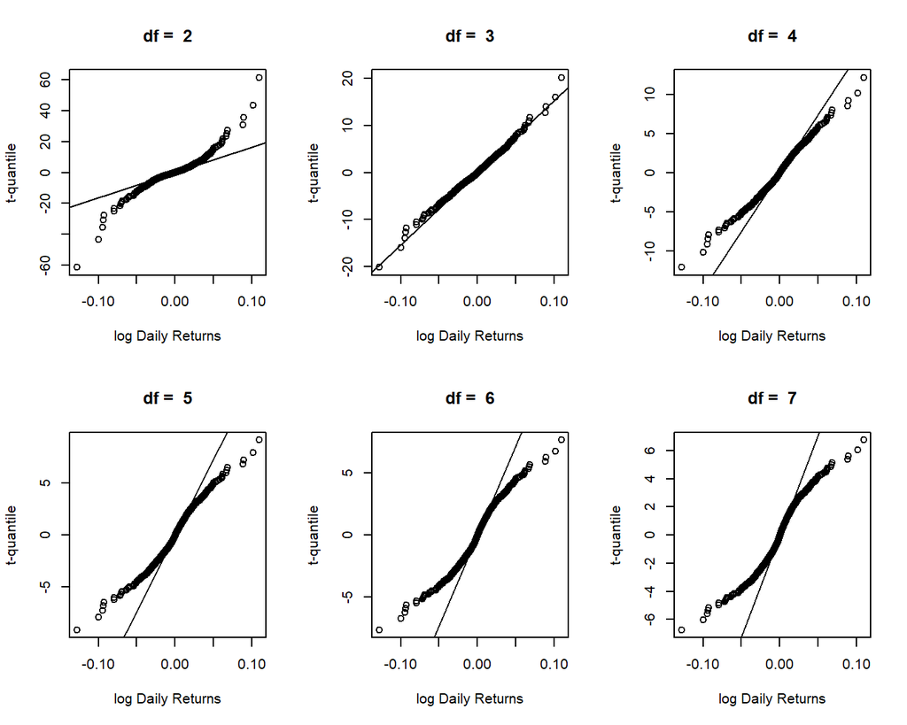

```r
par(mfrow = c(2, 3))
logR      = as.vector(dailyReturn(Ad(GSPC), type="log"))  # set up daily log return vector used in code
n         = length(logR)
 q_grid   = (1:n) / (n + 1)
 df_grid  = 2:7

for(df in df_grid)  {
  qqplot(logR, qt(q_grid,df),
  main = paste("df = ", df), ylab="t-quantile", xlab="log Daily Returns" )
  abline(lm(qt(c(0.25, 0.75), df = df) ~ quantile(logR, c(0.25, 0.75))))
}
```

**Problem 4: What does the code q_grid = (1:n) / (n + 1) do? What does qt(q.grid, df = df[j]) do? What does paste do?**  
The q_grid object calculates the endpoints for equally spaced intervals on the 0 to 1 line segment given the total number of log daily returns we have.  
The qt object then uses these endpoints to calculate t-quantiles for each interval endpoint given a specified value of degrees of freedom. This sets up the q-q plot for a t-distribution.  
Paste converts and combines the arguments of the function into a character string for the plot titles (here the # of deg. freedom).

# Question 6: Density Plots

**Setup.**

```r
library("fGarch")
```

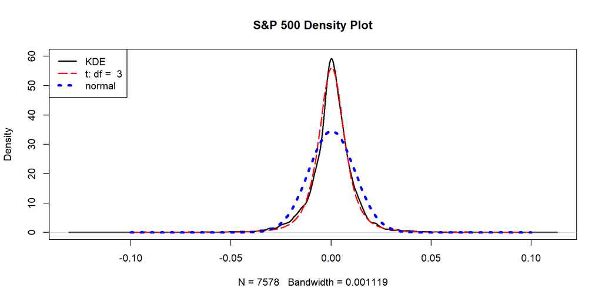

```r
x=seq(-0.1, 0.1,by = 0.001)
par(mfrow = c(1, 1))
df = 3
mad_t = mad(logR, constant = sqrt(df / (df - 2)) / qt(0.75, df))
plot(density(logR), lwd = 2, ylim = c(0, 60), main="S&P 500 Density Plot")
lines(x, dstd(x, mean = mean(logR), sd = mad_t, nu = df), lty = 5, lwd = 2, col = "red")
lines(x, dnorm(x, mean = mean(logR), sd = sd(logR)), lty = 3, lwd = 4, col = "blue")
legend("topleft", c("KDE", paste("t: df = ",df), "normal"), lwd = c(2, 2, 4), lty = c(1, 5, 3),
col = c("black", "red", "blue"))
```

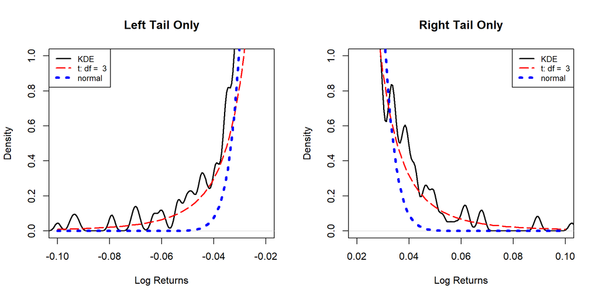

```r
# zoom in plot, left tail
par(mfrow = c(1, 2))
plot(density(logR), lwd = 2, ylim = c(0, 1), xlim=c(-.1,-0.02), main="Left Tail Only", xlab = "Log Returns")
lines(x, dstd(x, mean = mean(logR), sd = mad_t, nu = df), lty = 5, lwd = 2, col = "red")
lines(x, dnorm(x, mean = mean(logR), sd = sd(logR)), lty = 3, lwd = 4, col = "blue")
legend("topleft", c("KDE", paste("t: df = ",df), "normal"), lwd = c(2, 2, 4), lty = c(1, 5, 3), col = c("black", "red", "blue"), cex=.8)
# zoom in plot, right tail
plot(density(logR), lwd = 2, ylim = c(0, 1), xlim=c(0.02,0.1), main="Right Tail Only", xlab = "Log Returns")
lines(x, dstd(x, mean = mean(logR), sd = mad_t, nu = df), lty = 5, lwd = 2, col = "red")
lines(x, dnorm(x, mean = mean(logR), sd = sd(logR)), lty = 3, lwd = 4, col = "blue")
legend("topright", c("KDE", paste("t: df = ",df), "normal"), lwd = c(2, 2, 4), lty = c(1, 5, 3), col = c("black", "red", "blue"), cex=.8)
```

**Problem 6: Do either of the parametric models provide a reasonably good fit to the S&P 500 index? Explain.**  
Yes, the t-distribution with 3 degrees of freedom provides a fairly good fit as the density plot matches up very well to the kernel density estimator (KDE). The KDE is only slightly more peaked than the t-distribution and the tails match up well. The Normal Distribution does not match up well at all, with lighter/shorter tails and much shorter and wider peak.

**Problem 7: Which bandwidth selector is used as the default by density? What is the default kernel?**  
The default bandwidth selector is bw.nrd0 which is Silverman’s rule-of-thumb for selecting the bandwidth of a gaussian estimator (here we get 0.0011). The default kernel is the gaussian kernel.